# Project Final Submission Template

### Step 1a: Planning

#### Identify the information in the file your program will read

Describe (all) the information that is available. Be sure to note any surprising or unusual features. (For example, some information sources have missing data, which may be blank or flagged using values like -99, NaN, or something else.)

Caffeine.csv contains a list of names of beverages that commonly contain caffeine. The mass of caffeine (mg), the beverage volume (mL), the number of calories, and the type (eg. energy drink, coffee, tea) is provided for each named beverage. Some beverages have been listed to contain 0 calories, and/or 0 caffeine.

### Step 1b: Planning

#### Brainstorm ideas for what your program will produce

#### Select the idea you will build on for subsequent steps

You must brainstorm at least three ideas for graphs or charts that your program could produce and choose the one that you'd like to work on. You can choose between a line chart, histogram, bar chart, scatterplot, or pie chart.

If you would like to change your project idea from what was described in the proposal, you will need to get permission from your project TA. This is intended to help ensure that your new project idea will meet the requirements of the project. Please see the project proposal for things to be aware of when communicating with your project TA.

- A line graph comparing caffeine content over time when given a list of drinks using half-life calculations. <- my chosen idea
- A table that shows a list of drinks (based on a given list of drinks) whose caffeine contents will have depleted within a given timeframe (ie. before the average adult's bedtime)
- A program that takes a list of drinks and returns a bar chart comparing the average caffeine contents per type of drink included (eg. each bar represents a drink type).

### Step 1c: Planning

#### Write or draw examples of what your program will produce

You must include an image that shows what your chart or plot will look like. You can insert an image using the Insert Image command near the bottom of the Edit menu.

Half-life is the amount of time it takes for a substance to be reduced to half of its original amount. Caffeine has a half-life as it is metabolized by the human body. According to the National Institutes of Health, the average half-life of caffeine is around 5 hours. As such, it remains in the body for extended periods of time while the kidneys work on eliminating it. This program aims to calculate the half-lives of an inputted list of drinks and tabulate each drink in a line graph showing mass of caffeine as a function over time. Time is not given in caffeine.csv, but it is independant of this data, and points are determined based on the literature-defined half-life.

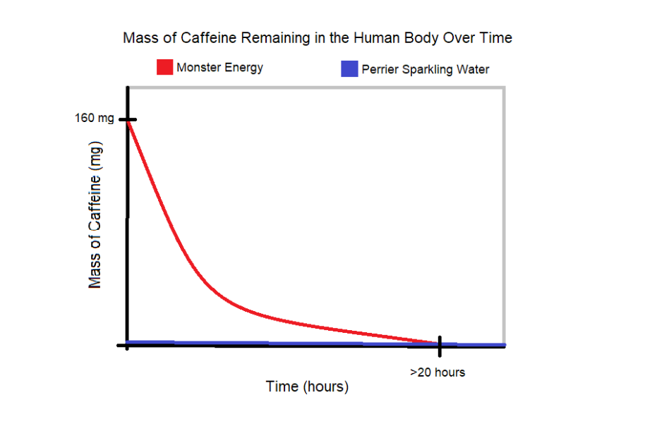

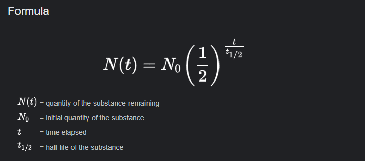

### Step 2a: Building

#### Document which information you will represent in your data definitions

Before you design data definitions in the code cell below, you must explicitly document here which information in the file you chose to represent and why that information is crucial to the chart or graph that you'll produce when you complete step 2c.

Drink name, mass of caffeine.

#### Design data definitions

```python
### READ COMMENTS BEFORE SUBMITTING
```

```python
import matplotlib.pyplot as plt
from cs103 import *
import csv
from typing import NamedTuple, List
from enum import Enum

##################
# Data Definitions

### Compound Definition for Drink ###

Drink = NamedTuple("Drink", [("name", str),
                             ("caffeine", int)]) # in range [0, ...)
# interp. A Drink (obtained from caffeine.csv) has a name, and known caffeine content (in mg)
D0 = Drink("Null", 0)
D1 = Drink("Tonic Water", 0)
D2 = Drink("Killer Coffee", 430)
D3 = Drink("Redline Max 300", 300)

@typecheck
def fn_for_drink(d: Drink) -> ...:
    #template based on Compound (2 fields)
    return (d.name,
            d.caffeine)

### List Definition referencing Drink ###

#List[Drink]
#interp. a list of drinks based on Drink

LOD0 = []
LOD1 = [D1]
LOD2 = [D1, D2, D3]
LOD3 = [D2, D3]

@typecheck
def fn_for_lod(lod: List[Drink]) -> ...:
    #template based on Arbitrary-sized and reference rule
    #description of the accumulator
    #acc = ...  #type: ...
    for d in lod:
        acc = (acc, fn_for_drink(d)) # ADD BACK ELLIPSES

    return (acc)  # ADD BACK ELLIPSES

###
```

### Step 2b and 2c: Building

#### Design a function to read the information and store it as data in your program

#### Design functions to analyze the data

Complete these steps in the code cell below. You will likely want to rename the analyze function so that the function name describes what your analysis function does.

Unless approved by your project TA, you **cannot** use libraries such as `numpy` or `pandas`. The project is meant as a way for you to demonstrate your knowledge of the learning goals in this course. While it is convinent to use external libraries, it will do all the work and will not help us gauge your mastery of the concepts.

You also cannot use built in list functions (e.g., `sum` or `average`) when writing code to do your substantial computation. Normally we encourage you to make use of what is already available but in this case, the final project involves demonstrating skills from class (e.g., how to work with a list). Using pre-built functions for this does not enable you to demonstrate what you know.

If you wish to change your project idea, you must **first** obtain permission from your TA. When contacting your TA, please provide a valid reason for why you want to change your project. Each time you change your topic idea, your TA will have to evaluate it to see if it will meet all of the project requirements. This is non-trivial task during one of the busiest times of the semester. As such, the deadline for project idea changes will be 3 business days before the deadline. Note that the deliverable deadline will not be extended and there is no compensation for the time you spent on the previous idea.

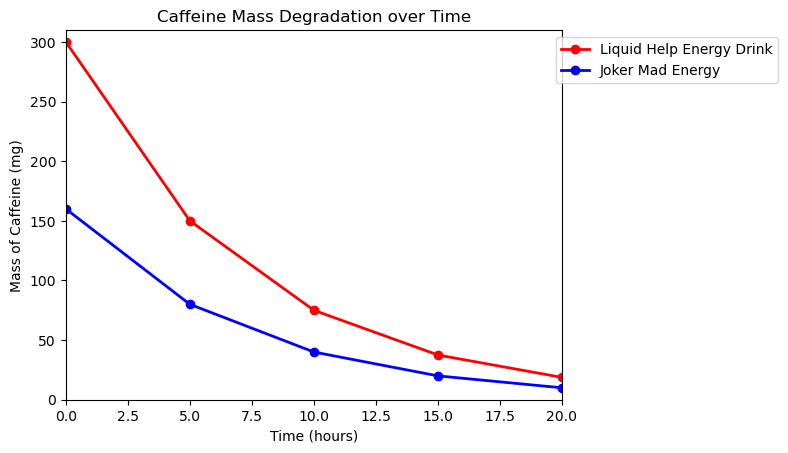

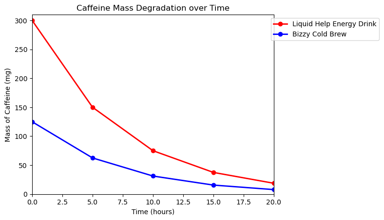

```
2 of 2 tests passed
```

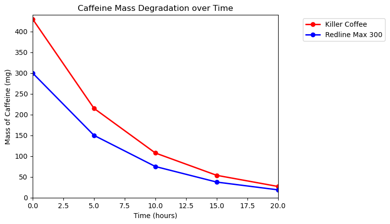

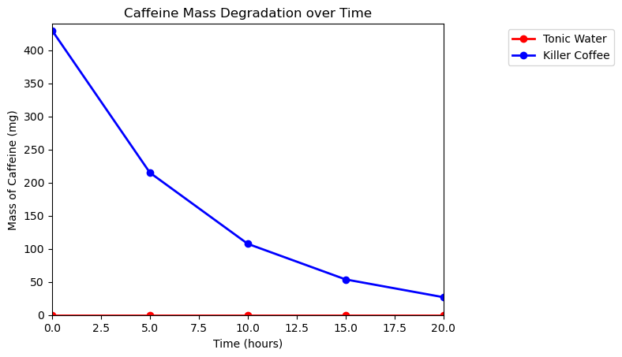

```
2 of 2 tests passed
2 of 2 tests passed
3 of 3 tests passed
3 of 3 tests passed
2 of 2 tests passed
2 of 2 tests passed
```

```python
#############
# Functions #


### Variables ###

T = [0, 5.0, 10.0, 15.0, 20.0]  # Time(s) @ 0, 5, 10, 15, and 20 seconds
T1 = [0, 5.0, 10.0, 15.0]  # Time(s) @ 0, 5, 10, and 15 seconds


#####################
### Main Function ###

@typecheck
def main(filename: str, d1: Drink, d2: Drink, time: List[float]) -> None:
    """
    Reads the file from given filename, analyzes the data, returns the result, which is a line graph showing the mass of caffeine (on the y-axis)
    ... for a chosen two drinks over a fixed list of times (in hours). Each value of time will be plotted on the x-axis.

    The amount of time it takes for the mass of caffeine to be half its volume is 5 hours. This value will be used in all calculations.
    """
    # Template from HtDAP, based on function composition
    return show_line_graph(drinks_halflife(read(filename), d1, d2, time), time, read(filename), d1, d2)

##################
### Line Graph ###

def show_line_graph(mass: List[float], time: List[float], lod: List[Drink], d1: Drink, d2: Drink) -> None:
    """
    returns a line graph comparing the masses (in mg) of caffeine of two drinks over elapsed time.

    Time (in hours) will be on the x-axis, with mass (in mg) of caffeine on the y-axis.

    One drink will be represented with a blue line, while another will be represented with a red line.
    """
    #return None #stub
    # Template based on Visualization

    mass_drink1 = mass[:get_length(time)]
    mass_drink2 = mass[get_length(time):]

    plt.xlabel('Time (hours)')
    plt.ylabel('Mass of Caffeine (mg)')
    plt.title('Caffeine Mass Degradation over Time')

    plt.axis([0,(time[-1]),0,(max_mass(mass)+10)])

    line1 = plt.plot(time, mass_drink1)
    line2 = plt.plot(time, mass_drink2)

    plt.setp(line1, color='r', linewidth=2.0, marker="o")
    plt.setp(line2, color='b', linewidth=2.0, marker="o")

    # legend
    plt.legend([(sort_lod(lod, d1)).name, (sort_lod(lod, d2)).name], bbox_to_anchor=(1.45, 1), loc=1)

    # showing the plot...
    plt.show()

    return None

#####################
### Read Function ###

def read(filename: str) -> List[Drink]:
    """
    reads information from the specified file and returns data as a Drink from two columns: drink (drink name) and Caffeine (in mg).
    ... drink provides the drink name that will help identify each Drink, while Caffeine (mg) will be needed for half-life calculations.
    """
    #return []  #stub
    # Template from HtDAP
    # lod contains the result so far
    lod = [] # type: List[Consumed]

    with open(filename) as csvfile:

        reader = csv.reader(csvfile)
        next(reader) # skip header line

        for row in reader:
            d = Drink(row[0], parse_int(row[3]))
            lod.append(d)

    return lod


#######################################################
### Analyze Function -- renamed to "drink_halflife" ###

def drinks_halflife(lod: List[Drink], d1: Drink, d2: Drink, time: List[float]) -> List[float]:
    """
    Takes a list of Drinks, and two chosen drinks from the list, and calculates their mass (in mg) of caffeine remaining after fixed times, based on
    ... variable "T" (in hours)

    Returns a list of all calculated masses (in mg) after the elapsed times.

    Assumptions: List[Drink] contains both of the chosen drinks
    """
    #return [] #stub
    # Template copied from List[Drink], based on HTDAP and Reference Rule
    # masses contains every calculated mass after the elapsed time has passed, based on halflife.
    masses = []  #type: List[float]

    for d in lod:
        mass1 = calculate_masses(sort_lod(lod, d1), time)
        mass2 = calculate_masses(sort_lod(lod, d2), time)
        masses = mass1 + mass2

    return masses


def sort_lod(lod: List[Drink], d0: Drink) -> Drink:
    """
    returns the appropriate Drink that matches d0, when given a list of Drinks
    """
    #return D0 #stub
    # Template copied from List[Drink] and based on Drink
    # drink contains the Drink that matches d0, while iterating through lod
    drink = D0  #Type: Drink

    for d in lod:
        if d == d0:
            drink = d

    return drink


def calculate_masses(d: Drink, time: List[float]) -> List[float]:
    """
    calculates a list of masses based on a halflife formula for a given Drink and a list of times. Each time will have its own mass associated
    ... with it
    """
    #return [] #stub
    # Template based on Drink and time, which is based on Arbitrary-sized with Atomic Simple values
    # mass stores every mass calculated based on time seen so far
    mass = []  #type: List[float]

    for t in time:
        mass.append(d.caffeine*((0.5)**(t/5)))

    return mass


def get_length(time: List[float]) -> int:
    """
    returns an integer representing the number of items in a list of times
    """
    #return 1 #stub
    # Template based on Arbitrary-Sized, and Atomic Simple
    # acc counts what has been seen so far
    acc = 0  #type: int

    for t in time:

        acc = acc + 1

    return acc

def max_mass(mass: List[float]) -> float:
    """
    returns the maximum mass (in mg) within a list of masses
    """
    #return 1.0 #stub
    # Template based on Arbitrary-Sized, and Atomic Simple
    # acc stores the largest value seen so far
    acc = 0.0  #type: float

    for m in mass:
        if m > acc:
            acc = m

    return acc


##########################
### EXAMPLES AND TESTS ###

# Examples for main
start_testing()
expect(main("caffeine_small2.csv", Drink("Liquid Help Energy Drink", 300), Drink("Joker Mad Energy", 160), T), None)   # Expecting a line graph
expect(main("caffeine.csv", Drink("Liquid Help Energy Drink", 300), Drink("Bizzy Cold Brew", 125), T), None)           # Expecting a line graph
summary()


# Examples for show_line_graph
start_testing()
expect(show_line_graph(drinks_halflife(LOD3, D2, D3, T), T, LOD3, D2, D3), None)
expect(show_line_graph(drinks_halflife(LOD2, D1, D2, T), T, LOD2, D1, D2), None)
summary()


# Examples and tests for read
start_testing()
expect(read("caffeine_small.csv"), [Drink("Costa Coffee", 277),
                             Drink("Coffee Friend Brewed Coffee", 145),
                             Drink("Hell Energy Coffee", 100),
                             Drink("Killer Coffee (AU)", 430),
                                   Drink("Nescafe Gold", 66)])
expect(read("caffeine_small2.csv"), [Drink("Joker Mad Energy", 160),
                             Drink("Liquid Help Energy Drink", 300)])
summary()


# Examples and tests for drink_halflife
start_testing()
expect(drinks_halflife([], D1, D2, T), [])
expect(drinks_halflife(LOD2, D1, D3, T1), [0, 0, 0, 0, 300, 150, 75, 37.5])
expect(drinks_halflife(LOD3, D2, D3, T), [430, 215, 107.5, 53.75, 26.875, 300, 150, 75, 37.5, 18.75])
summary()


# Examples and tests for sort_lod
start_testing()
expect(sort_lod(LOD0, D1), D0)
expect(sort_lod(LOD1, D1), D1)
expect(sort_lod(LOD2, D3), D3)
summary()


# Examples and tests for calculate_masses
start_testing()
expect(calculate_masses(D1, T), [0.0, 0.0, 0.0, 0.0, 0.0])
expect(calculate_masses(D2, T1), [430, 215, 107.5, 53.75])
summary()

# Examples and tests for get_length
start_testing()
expect(get_length([1,2,3]), 3)
expect(get_length([1]), 1)
summary()
```

### Final Graph/Chart

Now that everything is working, you **must** call `main` on the intended information source in order to display the final graph/chart:

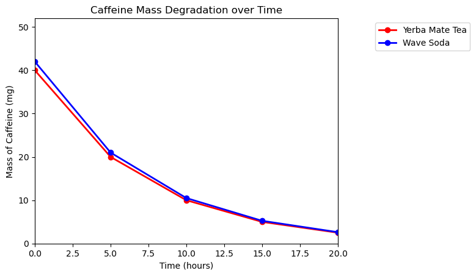

```python
main("caffeine.csv", Drink("Yerba Mate Tea", 40), Drink("Wave Soda", 42), T)
```

```python
# Be sure to select ALL THE FILES YOU NEED (including csv's)
# when you submit. As usual, you cannot edit this cell.
# Instead, run this cell to start the submission process.
from cs103 import submit

COURSE = 130118
# Uncomment the ASSIGNMENT row for your section
ASSIGNMENT = 1740562 #if you are in section 201
# ASSIGNMENT = 1788053 #if you are in section 202

submit(COURSE, ASSIGNMENT)

# If your submission fails, SUBMIT by downloading your files and uploading them
# to Canvas. You can learn how on the page "How to submit your Jupyter notebook"
# on our Canvas site.
```

# Please double check your submission on Canvas to ensure that the right files (Jupyter file + CSVs) have been submitted and that the files do not contain unexpected errors.

**You should always check your submission on Canvas. It is your responsibility to ensure that the correct file has been submitted for grading.** Regrade or accomodation requests using reasoning such as "I didn't realize I submitted the wrong file"/"I didn't realize the submission didn't work"/"I didn't realize I didn't save before submitting so some of my work is missing" will not be considered.